# How to Survive the Titanic - A Data Voyage

Ryan Tillis

11/10/2016

## Synopsis

The goal is to predict titanic survivors from a dataset that features the passenger’s class, name, sex, sge, number of siblings/spouses aboard, number of parents/child aboard, ticket number, fare, and the embarking port. This data set has been looked at many times, and has Random Forest written all over it. The goal is to provide a brief data exploration with exploratory visualizations, feature discrimination, and predictive modeling.

## Exploring the Data

We start by loading the data and examing the first 6 rows.

```r
##Include length of name metric
##Include Pictures for class selection
##Make Fare input dependent on class
#Picture of deck
test <- read.csv("test.csv")
train <- read.csv("train.csv")
train <- as.data.table(train)
test. <- as.data.table(test)
head(train)
```

```
##    PassengerId Survived Pclass
## 1:           1        0      3
## 2:           2        1      1
## 3:           3        1      3
## 4:           4        1      1
## 5:           5        0      3
## 6:           6        0      3
##                                                   Name    Sex Age SibSp
## 1:                             Braund, Mr. Owen Harris   male  22     1
## 2: Cumings, Mrs. John Bradley (Florence Briggs Thayer) female  38     1
## 3:                              Heikkinen, Miss. Laina female  26     0
## 4:        Futrelle, Mrs. Jacques Heath (Lily May Peel) female  35     1
## 5:                            Allen, Mr. William Henry   male  35     0
## 6:                                    Moran, Mr. James   male  NA     0
##    Parch           Ticket    Fare Cabin Embarked
## 1:     0        A/5 21171  7.2500              S
## 2:     0         PC 17599 71.2833   C85        C
## 3:     0 STON/O2. 3101282  7.9250              S
## 4:     0           113803 53.1000  C123        S
## 5:     0           373450  8.0500              S
## 6:     0           330877  8.4583              Q
```

### Class

The class variable has 3 distinct levels. The largest group is in class 3 with a near even split between classes 1 and 2, slightly more in class 1.

```r
train$Pclass <- as.factor(train$Pclass)
summary(train$Pclass)
```

```
##   1   2   3
## 216 184 491
```

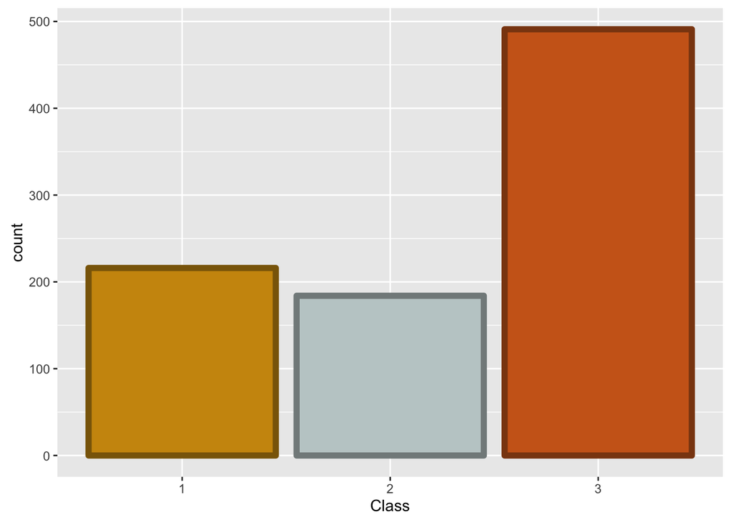

```r
ch <- ggplot(train, aes(x=Pclass)) + geom_bar(fill=c(colors()[78], colors()[16], colors()[55]), col=c(colors()[79], colors()[17], colors()[56]), lwd = 2)+labs(x="Class")
ch
```

### Name

Average length of a name is 27 characters with a max of 82.

```r
summary(sapply(as.character(unique(train$Name)),nchar))#Summary of lengths of name
```

```
##    Min. 1st Qu.  Median    Mean 3rd Qu.    Max.
##   12.00   20.00   25.00   26.97   30.00   82.00
```

### Sex

Nearly twice as many men

```r
summary(train$Sex)#Almost twice as many men
```

```
## female   male
##    314    577
```

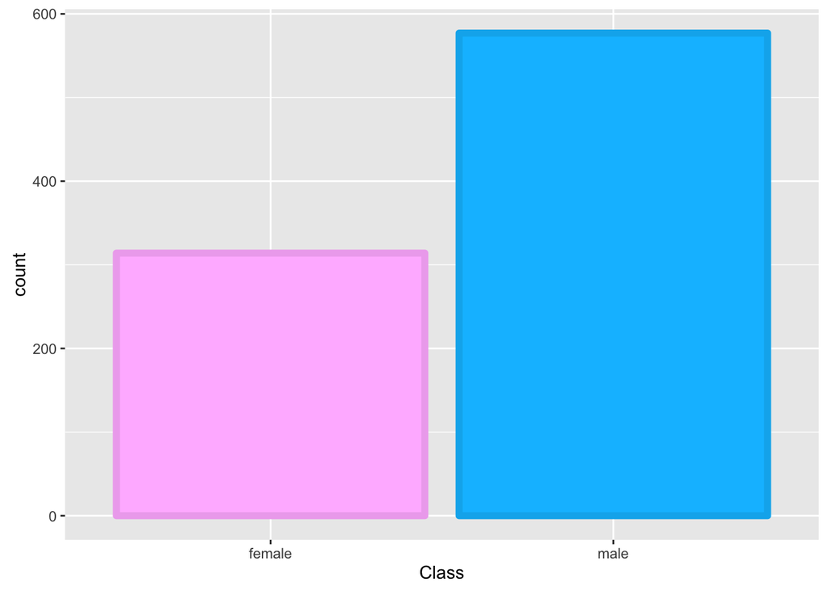

```r
sb <- ggplot(train, aes(x=Sex)) + geom_bar(fill=c(colors()[542], colors()[121]), col=c(colors()[543], colors()[123]), lwd = 2)+labs(x="Class")
sb
```

```r
#create Categorical variables for F123 and M123
```

### Age

Average age around 30 years old with 177 NA’s. Need to find a way to impute these values.

```r
summary(train$Age) #177 NA's, Median age is 28 aka born in 1884 (start of input),
```

```
##    Min. 1st Qu.  Median    Mean 3rd Qu.    Max.    NA's
##    0.42   20.12   28.00   29.70   38.00   80.00     177
```

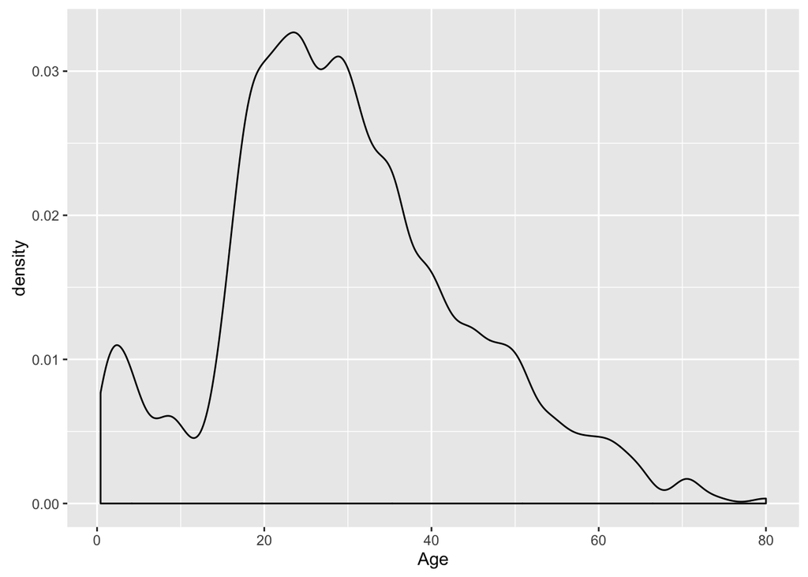

```r
ap <- ggplot(train, aes(x=Age))+geom_density(adjust=.5)
ap
```

### Siblings and Spouses

```r
unique(train$SibSp)
```

```
## [1] 1 0 3 4 2 5 8
```

```r
#Max Spouse is 1, create sibling data
#Max parents is 2, create children data
#Gather wealth data from embarking points
train$SibSp <- as.integer(train$SibSp) #possibly alone vs with family variable
summary(train$SibSp) #median is 0
```

```
##    Min. 1st Qu.  Median    Mean 3rd Qu.    Max.
##   0.000   0.000   0.000   0.523   1.000   8.000
```

```r
dim(train[SibSp > 0,])
```

```
## [1] 283  12
```

```r
dim(train[SibSp == 0,])
```

```
## [1] 608  12
```

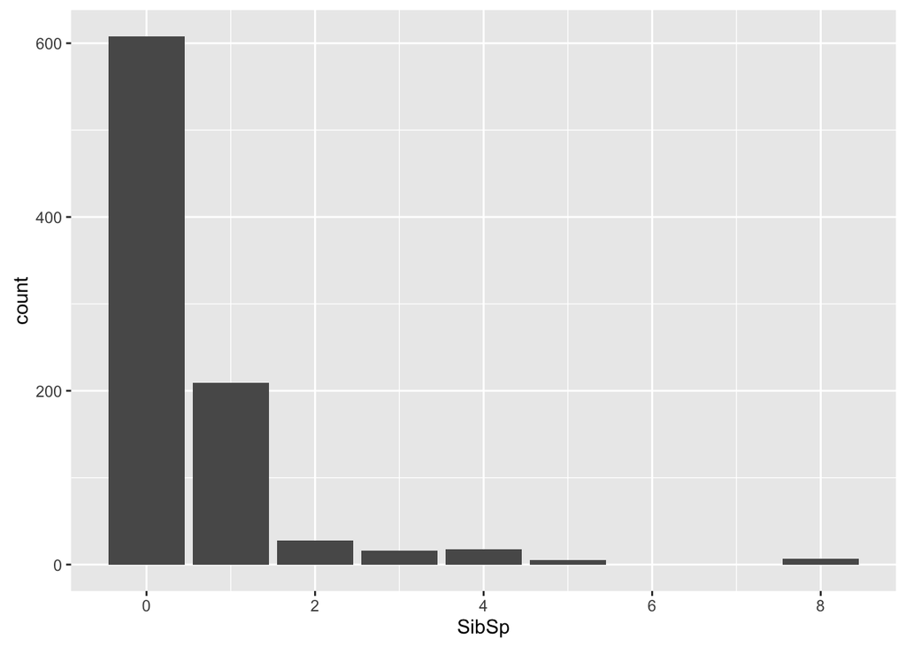

```r
sp <- ggplot(train, aes(x=SibSp))+geom_bar()
sp
```

### Parents and Children

This also suggests most people are without family. About 1/4 have parents or children on board.

```r
unique(train$Parch)
```

```
## [1] 0 1 2 5 3 4 6
```

```r
summary(train$Parch)
```

```
##    Min. 1st Qu.  Median    Mean 3rd Qu.    Max.
##  0.0000  0.0000  0.0000  0.3816  0.0000  6.0000
```

```r
dim(train[Parch > 0,])
```

```
## [1] 213  12
```

```r
dim(train[Parch == 0,])
```

```
## [1] 678  12
```

### Ticket

```r
length(unique(train$Ticket)) #Create Ticket pre and ticket num and LINE value all as non-integers
```

```
## [1] 681
```

```r
#Use ticket to predict cabin
```

### Fare

```r
train[Fare==0]#who gets a ride without paying? 15/861, all male, all from southhampton (more or less even split class)
```

```
##     PassengerId Survived Pclass                             Name  Sex Age
##  1:         180        0      3              Leonard, Mr. Lionel male  36
##  2:         264        0      1            Harrison, Mr. William male  40
##  3:         272        1      3     Tornquist, Mr. William Henry male  25
##  4:         278        0      2      Parkes, Mr. Francis "Frank" male  NA
##  5:         303        0      3  Johnson, Mr. William Cahoone Jr male  19
##  6:         414        0      2   Cunningham, Mr. Alfred Fleming male  NA
##  7:         467        0      2            Campbell, Mr. William male  NA
##  8:         482        0      2 Frost, Mr. Anthony Wood "Archie" male  NA
##  9:         598        0      3              Johnson, Mr. Alfred male  49
## 10:         634        0      1    Parr, Mr. William Henry Marsh male  NA
## 11:         675        0      2       Watson, Mr. Ennis Hastings male  NA
## 12:         733        0      2             Knight, Mr. Robert J male  NA
## 13:         807        0      1           Andrews, Mr. Thomas Jr male  39
## 14:         816        0      1                 Fry, Mr. Richard male  NA
```

[output cut: 17 more lines]

```r
length(unique(train$Fare)) #248 unique ticket prices, suggests 248 cabin assignment, use
```

```
## [1] 248
```

```r
train %>% group_by(Pclass) %>% summarise_each(funs(min, max, mean, median),Fare)
```

```
## # A tibble: 3 × 5
##   Pclass   min      max     mean  median
##   <fctr> <dbl>    <dbl>    <dbl>   <dbl>
## 1      1     0 512.3292 84.15469 60.2875
## 2      2     0  73.5000 20.66218 14.2500
## 3      3     0  69.5500 13.67555  8.0500
```

```r
train %>% group_by(Sex) %>% summarise_each(funs(min, max, mean, median),Fare) #Women pay way more for same (start of input)
```

```
## # A tibble: 2 × 5
##      Sex   min      max     mean median
##   <fctr> <dbl>    <dbl>    <dbl>  <dbl>
## 1 female  6.75 512.3292 44.47982   23.0
## 2   male  0.00 512.3292 25.52389   10.5
```

```r
train %>% group_by(Sex, Pclass) %>% summarise_each(funs(min, max, mean, median),Fare) #Women pay way more for same (start of input)
```

```
## Source: local data frame [6 x 6]
## Groups: Sex [?]
##
##      Sex Pclass     min      max      mean   median
##   <fctr> <fctr>   <dbl>    <dbl>     <dbl>    <dbl>
## 1 female      1 25.9292 512.3292 106.12580 82.66455
## 2 female      2 10.5000  65.0000  21.97012 22.00000
## 3 female      3  6.7500  69.5500  16.11881 12.47500
## 4   male      1  0.0000 512.3292  67.22613 41.26250
## 5   male      2  0.0000  73.5000  19.74178 13.00000
## 6   male      3  0.0000  69.5500  12.66163  7.92500
```

### Cabin

There are 148 declared cabin values, a lot are missing. It’s possible that the cabin information can be imputed based on ticket number, embarking port, and class but we’ll see.

```r
length(unique(train$Cabin)) #Fill in cabin data
```

```
## [1] 148
```

```r
datatable(data.frame(summary(train$Cabin))) # is it safe to impute cabin data?
```

|  | summary.train.Cabin. |
| --- | --- |
|  | 687 |
| B96 B98 | 4 |
| C23 C25 C27 | 4 |
| G6 | 4 |
| C22 C26 | 3 |
| D | 3 |
| E101 | 3 |
| F2 | 3 |
| F33 | 3 |
| B18 | 2 |

[output cut: 90 more lines]

### Embarked

Three ports

```r
unique(train$Embarked)
```

```
## [1] S C Q
## Levels:  C Q S
```

```r
summary(train$Embarked)
```

```
##       C   Q   S
##   2 168  77 644
```